# 基于评论文本的婚摄市场细分案例

狗熊会

案例难度：**

案例背景：婚纱摄影一直是每个女孩心中的渴望。自1992年婚纱摄影技术从台湾进入中国内地，婚摄产业获得了长足的发展。但自2013年起，我国结婚登记人数持续下滑，2020年仅达813.1万对，为 2013年的60%；与此同时，我国人均可支配收入逐步上升，2020年达3.2万，比2013年的1.8万上升78%。这背后暗含的是婚摄市场需求的变化：据腾讯营销洞察《2019婚摄写真用户洞察研究》，在婚纱摄影用户群体中，27%的用户偏好私人定制，14%的用户追求有个性的婚摄效果。但目前大多数商家陷入同质化产品内卷竞争当中，对目标市场定位的不足。为了帮助商家们切入细分市场，打造创造性、个性化的产品以赢得竞争，本案例将尝试通过用户聚类来识别细分市场。

本案例所使用的数据来自某一站式婚庆平台，包括婚摄产品所属商家信息(data_shop.dat)，婚摄产品信息(package_params_all.dat)，部分婚摄产品评论(comment_seg_trim.Rdata)等。

这个案例的学习目标包括：  
1.了解婚庆平台产品数据及评论文本数据；  
2.学会对数据做基本的描述性分析，并且适当解读；  
3.建立聚类模型，对聚类结果进行适当解读。

## 任务一

读入婚摄产品的套餐参数数据(package_params_all.dat)，里面包含全部的描述信息。 将拍摄场景类型(scenes)绘制成饼图，分为三类：纯内景、纯外景、剩下的归入内外景结合。并标注出类型及百分比。 将内景数(inner_scene)和外景数(outer_scene)绘制成分组条形图，组别为内景和外景。 对绘制图像进行分析。

```r
# 设置路径
setwd('E:/finance/bearclass/final project/casepro')

# 载入数据
package_param_all = read.csv("package_param_all.dat", sep="")
head(package_param_all)
```

```
Output:                  code_url bride_cloth bridegroom_cloth     scenes inner_scene
Output: 1 /package/detail_1094778          NA               NA       <NA>          NA
Output: 2 /package/detail_1848865          NA               NA 内外景结合           2
Output: 3 /package/detail_1848750           6                6 内外景结合           3
Output: 4 /package/detail_1848469           5                5 内外景结合           3
Output: 5 /package/detail_1848378           5                5 内外景结合           3
Output: 6 /package/detail_1848338           4                4 内外景结合           2
Output:   outer_scene day_num pic_num ps_num book_num grapher makeupr lightin mu_assist
Output: 1          NA      NA      10      3       NA    资深    资深    <NA>      <NA>
Output: 2          NA       2     220     90       90    总监    总监      有        有
Output: 3           3       1     180     70       70    总监    总监      有        有
Output: 4           2       1     160     62       62    总监    总监      有        有
Output: 5           2       1     150     50       50    总监    总监      有        有
Output: 6           2       1     150     40       40    总监    总监      有      <NA>
Output:   min_movie
Output: 1      <NA>
Output: 2        无
Output: 3        无
Output: 4        无
Output: 5        无
Output: 6        有
```

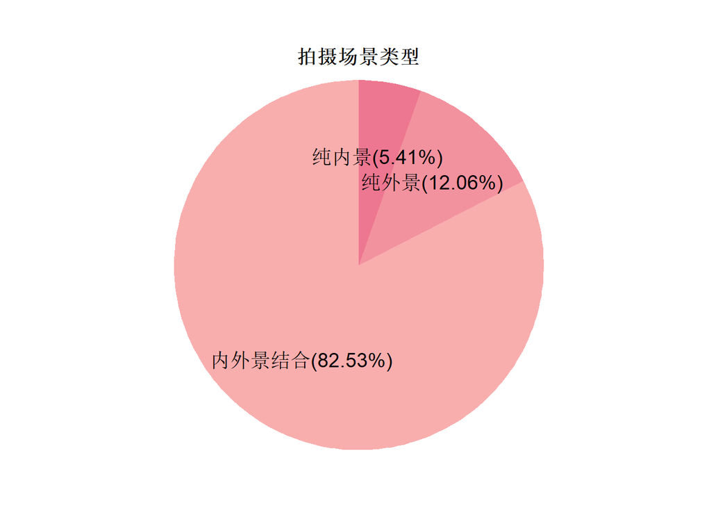

```r
# 提取拍摄场景字段
package_param_all$scenes[which(!(package_param_all$scenes %in% c('纯内景', '纯外景')))] = '内外景结合'
# 饼图标签
sdt = data.frame(type = names(table(package_param_all$scenes)), num = as.integer(table(package_param_all$scenes)))
myLabel = as.vector(sdt$type)
myLabel = paste(myLabel, "(", round(sdt$num / sum(sdt$num) * 100, 2), "%)", sep = "")

# 饼图
ggplot(sdt, aes(x = "", y = num, fill = type)) +
  geom_bar(stat = "identity", width = 4000, fill = colorRampPalette(c( "#ed7790", '#f9aeae'))(3)) +    #去除饼图中心的杂点
  coord_polar(theta = "y") +
  theme_minimal() + #去掉白色外框上的数字
  theme(axis.title.x = element_blank(),
        axis.title.y = element_blank(),
        panel.border = element_blank(),
        panel.grid=element_blank(),
        axis.ticks = element_blank(),
        plot.title=element_text(size=14, face="bold", hjust = 0.5, vjust = -10)) +
  theme(axis.text.x=element_blank()) +
  ggtitle("拍摄场景类型") +
  geom_text(aes(y = num/2 + c(0, cumsum(num)[-length(num)]), x = sum(num)/20, label = myLabel), size = 5, color = 'black') #在图中加百分比
```

```r
## 内外景数量
# 合并内外景字段
inner_num = cbind(package_param_all$inner_scene, rep('内景数', nrow(package_param_all)))
outer_num = cbind(package_param_all$outer_scene, rep('外景数', nrow(package_param_all)))
scenes_num = rbind(inner_num, outer_num)
scenes_num = data.frame(num = as.integer(scenes_num[,1]), type = as.factor(scenes_num[,2]))
head(scenes_num)
```

```
Output:   num   type
Output: 1  NA 内景数
Output: 2   2 内景数
Output: 3   3 内景数
Output: 4   3 内景数
Output: 5   3 内景数
Output: 6   2 内景数
```

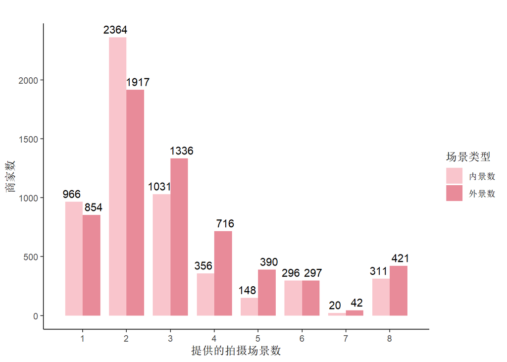

```r
# 内外景数分布
ggplot(data=scenes_num, mapping=aes(x=num,fill=type))+
  geom_bar(stat="count",width=0.8, position='dodge')+
  scale_fill_manual(values=c("#f9c5cc", "#E88B99"))+
  geom_text(stat='count',aes(label=..count..), color="black", ,position=position_dodge(1),vjust=-0.5)+
  scale_x_continuous(breaks = seq(1,8,1))+
  labs(title = '', x = '提供的拍摄场景数', y = '商家数', fill = '场景类型') +
  theme_classic()
```

提示：1、饼图中“内外景结合”占比最高，似乎多数产品提供了丰富的场景；但条形图中内外景数集中在2个，多数产品提供的场景其实非常有限。2、条形图中，低场景量下，含内景的产品更多，高场景量下，含外景的产品更多，相对而言外景更容易增加，而内景建设受成本约束大。

## 任务二

载入商家信息数据(data_shop.dat)，各列分别是所在城市(city)、网址码(urlcode)、评论数(comment_num)、好评率(comment_rate)、最低价(minprice)。 绘制评论数和最低价的条形图，并标注具体频数。评论数和最低价的数据带有单位，需要只保留里面的数字，不要单位。 + 在最低价图中，最低价为0指商家没有提供最低价信息，因此去掉最低价为0的数据，将最低价在9000以上的数据合并到一个组。 + 在评论数图中，去掉评论数为0的数据，可以自行适当调节分组。 对绘制的图进行分析。

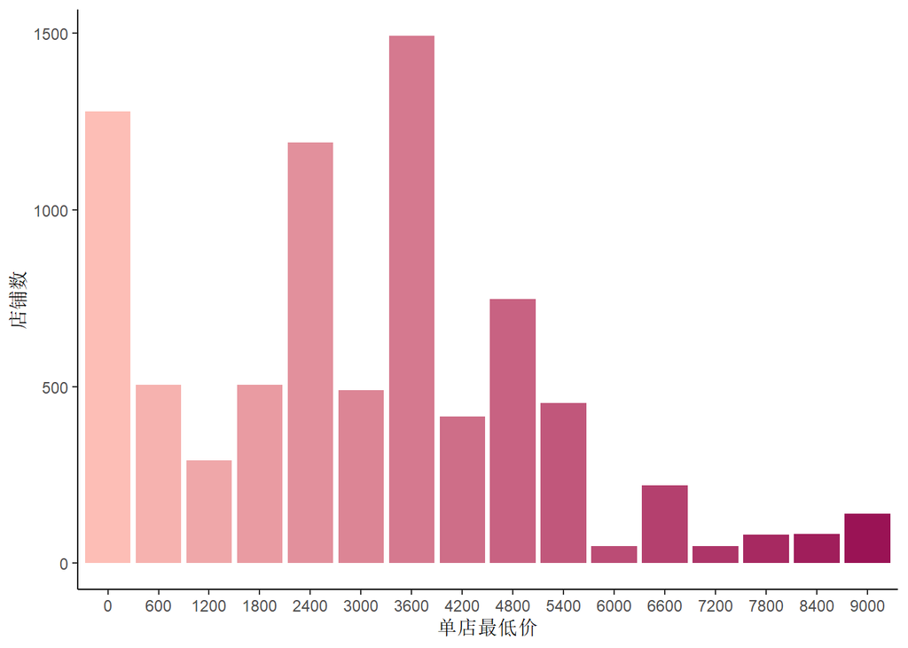

```r
data_shop = read.table('data_shop.dat')

# 取出数据
data_shop$minprice = unlist(lapply(data_shop$minprice, function(x){as.numeric(str_extract(x, '\\d+'))}))
data_shop$comment_num = unlist(lapply(data_shop$comment_num, function(x){as.numeric(str_extract(x, '\\d+'))}))

# 价格
# 数据分箱
min_p = data.frame(price = data_shop$minprice[which(data_shop$minprice>0)])
min_p$bin = cut(min_p$price, breaks = append(seq(0, 9000, 600), 1e+06), labels = seq(0, 9000, 600))
# 画图
ggplot(data=min_p, mapping=aes(x=bin, y=..count..))+
  geom_bar(fill=colorRampPalette(c("#fdbeb6", "#9a1355"))(length(levels(min_p$bin))))+
  xlab('单店最低价') + ylab('店铺数') +
  theme_classic()
```

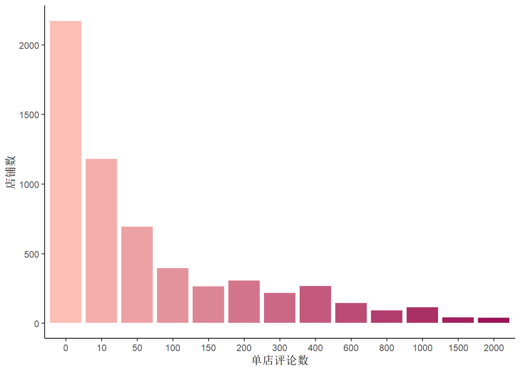

```r
# 评论数
# 分箱
comment_n = data.frame(num = data_shop$comment_num[which(data_shop$comment_num>0)])
breakr = c(0,10,50,100,150,200,300,400,600,800,1000,1500,2000)
comment_n$bin = cut(comment_n$num, breaks = append(breakr, 1e+05), labels = breakr)
ggplot(data=comment_n, mapping=aes(x=bin, y=..count..))+
  geom_bar(binwidth=1, color = 'white', fill = colorRampPalette(c("#fdbeb6", "#9a1355"))(length(breakr)))+
  xlab('单店评论数') + ylab('店铺数') +
  theme_classic()
```

提示：1、单店最低价集中3600左右，鲜有整体产品在8000元以上的商家，大部分商家定价能力不高；单店最低价分布较为集中，说明定价主要由市场决定。2、单店评论数高度集中在50条内，销售量不高，只有少数产品畅销。

## 任务三

载入分好词的评论(comment_seg_trim.Rdata)，以评论平均长度为下界，评论平均长度加评论长度样本方差为上界，去除长度落在此值域外的评论。 对剩下的样本计算词频，选取词频前100的词汇绘制词云图，观察其特征。

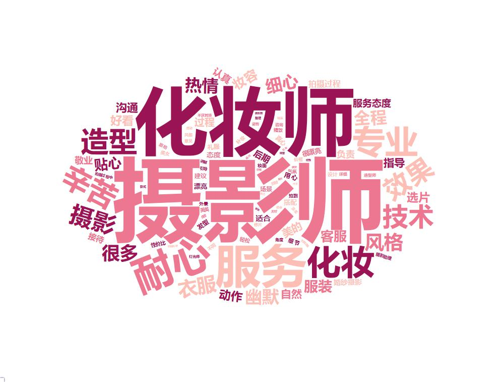

```r
# 载入分词词汇
load('comment_segmented.Rdata')

words2cloud = unlist(comment_segmented)
# 词频
freq2cloud = sort(table(words2cloud), decreasing = T)[1:100]
# 画图
wordc = wordcloud2(freq2cloud, fontFamily = "微软雅黑",
           color = rep(c('#ed7790','#9a1355',"#fdbeb6"), length.out=100))
saveWidget(wordc, "wordc.html", selfcontained = F)
webshot("wordc.html", "wordc.jpg", delay = 3)
```

提示：“化妆师”、“摄影师”等词词频远高于其他词汇，属于常用词，不代表用户倾向，后续分析应忽略此类常用词；“造型”、“服装”、“幽默”、“效果”等其他词属于产品不同维度，具有分类参考性。

## 任务四

修建分词词汇，去除前100高频词，保留余下词汇中前100高频词作为特征词。 根据提取的特征词建立tf-idf矩阵，可以用text2vec包，先计算DTM矩阵，再转换为TFIDF矩阵。得到的TFIDF矩阵是个稀疏矩阵，查看矩阵前5行5列。

```r
# 设置分词迭代器
it = itoken(comment_segmented, progressbar = FALSE)
comment_vocab = create_vocabulary(it)

# 修建词汇
comment_vocab_pruned = prune_vocabulary(comment_vocab, vocab_term_max = 200)
comment_vocab_kick = prune_vocabulary(comment_vocab_pruned, vocab_term_max = 100)
words_kept = setdiff(comment_vocab_pruned$term, comment_vocab_kick$term)
comment_vocab_pruned=comment_vocab_pruned[which(comment_vocab_pruned$term %in% words_kept),]

# 设置形成语料文件
vectorizer = vocab_vectorizer(comment_vocab_pruned)
# 先转为dtm矩阵
comment_dtm = create_dtm(it, vectorizer)

# 设置TFIDF编译器
tfidf = TfIdf$new()
# 转换成TFIDF矩阵
comment_tfidf = fit_transform(comment_dtm, tfidf)
comment_tfidf[1:5,1:5]
```

```
Output: 5 x 5 sparse Matrix of class "dgCMatrix"
Output:        环境 感动 清新 很快 感受
Output: 1 3.7225340    .    .    .    .
Output: 2 0.9306335    .    .    .    .
Output: 3 .            .    .    .    .
Output: 4 .            .    .    .    .
Output: 5 .            .    .    .    .
```

## 任务五

载入填补好的TFIDF矩阵(comment_tfidf_case.Rdata)，用kmeans算法将分为4类，取出每个特征词的聚类中心，并根据分成的组绘制词云。 为了突出组内差异，可以对数据进行适当变换，然后绘制每个组的词云图。 观察每个组的词云，你认为商家可以据此开发什么样的商品？

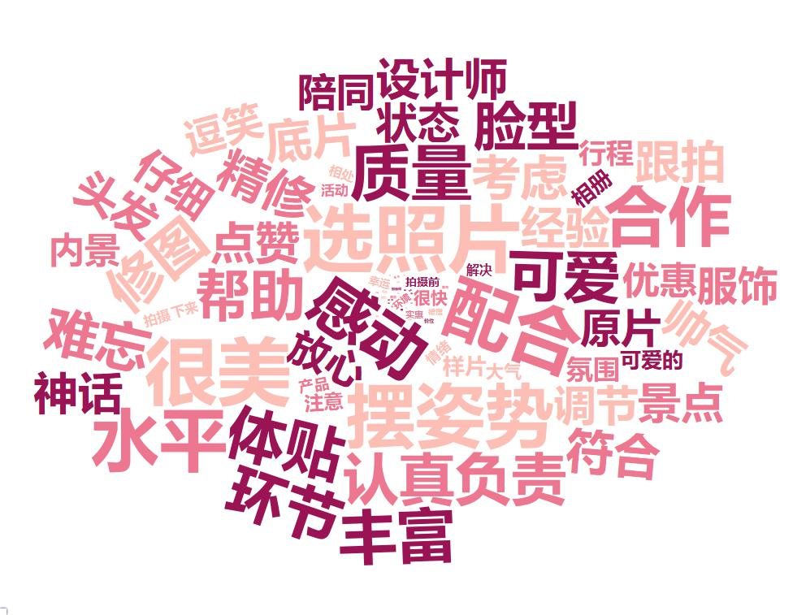

```r
# 载入数据
load('comment_tfidf_case.Rdata')

# 进行聚类
kcluster4 = kmeans(comment_tfidf_case, 4, iter.max = 100)
# 聚类中心
centers = kcluster4$centers
colnames(centers) = colnames(comment_tfidf_case)

# 画词云
# 三次方放大
group1 = data.frame(word = colnames(centers), freq = centers[1,]^3)

cloud1 = wordcloud2(group1,
           color = rep(c('#ed7790','#9a1355',"#fdbeb6"), length.out=100), fontFamily = '微软雅黑', size = 0.5)
saveWidget(cloud1, "cloud1.html", selfcontained = F) #先保存为网页格式
webshot("cloud1.html", "cloud1.jpg", delay = 3) #再依据网页格式生成jpg图片格式
```

第二组

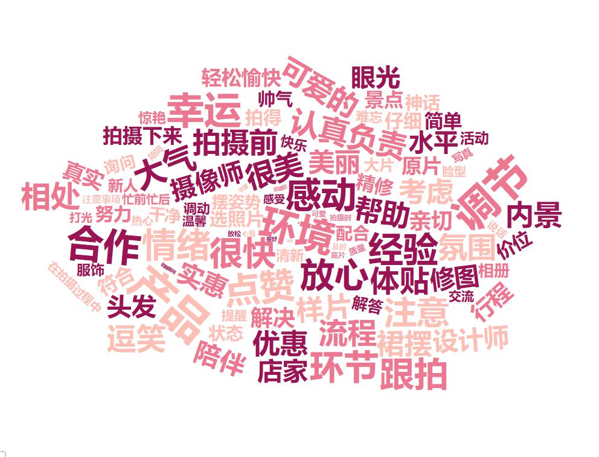

```r
group2 = data.frame(word = colnames(centers), freq = centers[2,]^3)

cloud2 = wordcloud2(group2,
           color = rep(c('#ed7790','#9a1355',"#fdbeb6"), length.out=100), fontFamily = '微软雅黑', size = 0.4)
saveWidget(cloud2, "cloud2.html", selfcontained = F)
webshot("cloud2.html", "cloud2.jpg", delay = 3)
```

第三组

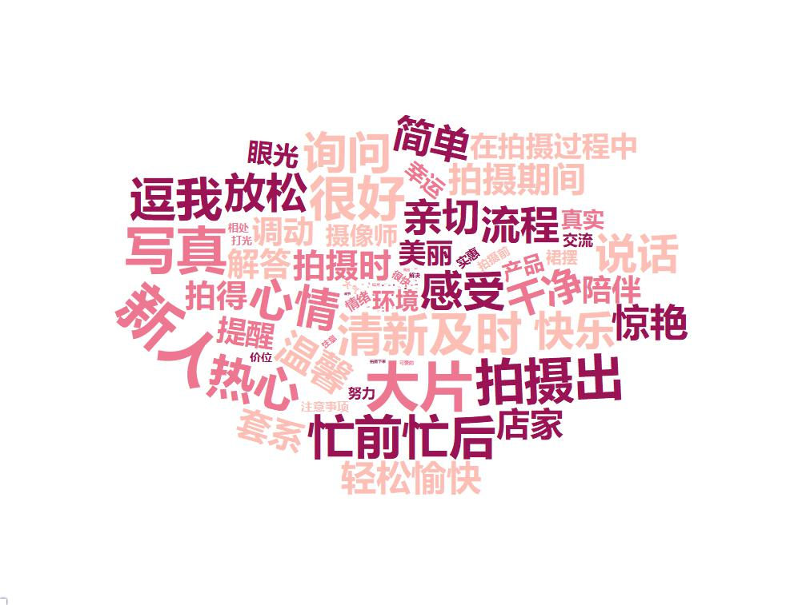

```r
group3 = data.frame(word = colnames(centers), freq = centers[3,]^3)

cloud3 = wordcloud2(group3,
           color = rep(c('#ed7790','#9a1355',"#fdbeb6"), length.out=100), fontFamily = '微软雅黑', size = 0.4)
saveWidget(cloud3, "cloud3.html", selfcontained = F)
webshot("cloud3.html", "cloud3.jpg", delay = 3)
```

第四组

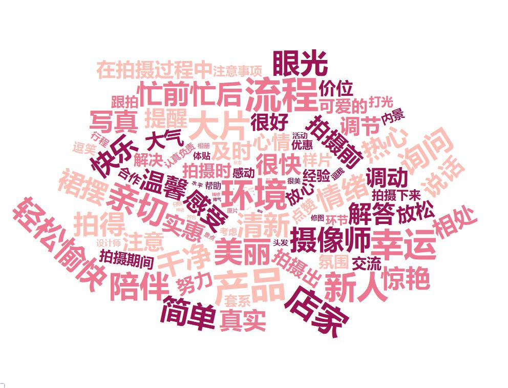

```r
group4 = data.frame(word = colnames(centers), freq = centers[4,]^3)

cloud4 = wordcloud2(group4,
           color = rep(c('#ed7790','#9a1355',"#fdbeb6"), length.out=100), fontFamily = '微软雅黑', size = 0.4)
saveWidget(cloud4, "cloud4.html", selfcontained = F)
webshot("cloud4.html", "cloud4.jpg", delay = 3)
```